# IDS investigation worksheet

by YIS:Yuening Yin, Isabella Lam, Serena Tam

2026-11-27

**Note:** You can use this file as you ‘working document’ where you can try out various investigation ideas and keep notes about your findings. How you use and structure this file is up to you. It is recommended that you keep notes about what you are investigating and what you find as this will make the process of creating your presentation and report easier. Please note that you *do not* need to submit this file as part of your group project.

```r
library(tidyverse)
library(tidymodels)
# Add any other libraries here
```

```r
# load your data
crime_data <- read.csv(
  "data/communities.data",
  header = FALSE,
  na.strings = "?",
  stringsAsFactors = FALSE
)

name_lines <- readLines("data/communities.names")
attribute_lines <- grep("@attribute", name_lines, value = TRUE)

variable_names <- sub("@attribute ", "", attribute_lines)
variable_names <- sub(" .*", "", variable_names)

length(variable_names)
```

```
## [1] 128
```

```r
colnames(crime_data) <- variable_names
```

# Stage1 Modeling Data

### Stage1.1 Dataset Structure

```r
# Overall dimensions
dim(crime_data)
```

```
## [1] 1994  128
```

```r
# Number of observations
nrow(crime_data)
```

```
## [1] 1994
```

```r
# Number of variables
ncol(crime_data)
```

```
## [1] 128
```

```r
# Names of all variables
names(crime_data)
```

```
##   [1] "state"                 "county"                "community"
##   [4] "communityname"         "fold"                  "population"
##   [7] "householdsize"         "racepctblack"          "racePctWhite"
##  [10] "racePctAsian"          "racePctHisp"           "agePct12t21"
##  [13] "agePct12t29"           "agePct16t24"           "agePct65up"
##  [16] "numbUrban"             "pctUrban"              "medIncome"
##  [19] "pctWWage"              "pctWFarmSelf"          "pctWInvInc"
##  [22] "pctWSocSec"            "pctWPubAsst"           "pctWRetire"
##  [25] "medFamInc"             "perCapInc"             "whitePerCap"
##  [28] "blackPerCap"           "indianPerCap"          "AsianPerCap"
##  [31] "OtherPerCap"           "HispPerCap"            "NumUnderPov"
##  [34] "PctPopUnderPov"        "PctLess9thGrade"       "PctNotHSGrad"
##  [37] "PctBSorMore"           "PctUnemployed"         "PctEmploy"
##  [40] "PctEmplManu"           "PctEmplProfServ"       "PctOccupManu"
##  [43] "PctOccupMgmtProf"      "MalePctDivorce"        "MalePctNevMarr"
```

[output cut: 28 more lines]

```r
# Types of variables
variable_types <- table(sapply(crime_data, class))

knitr::kable(
  as.data.frame(variable_types),
  col.names = c("Variable Type", "Number of Variables"),
  caption = "Types of Variables in the Dataset"
)
```

Types of Variables in the Dataset

| Variable Type | Number of Variables |
| --- | --- |
| character | 1 |
| integer | 4 |
| numeric | 123 |

```r
#  Preview of the first six observations
knitr::kable(
  head(crime_data[, 1:10]),
  caption = "First Six Observations (First Ten Variables)"
)
```

First Six Observations (First Ten Variables)

| state | county | community | communityname | fold | population | householdsize | racepctblack | racePctWhite | racePctAsian |
| --- | --- | --- | --- | --- | --- | --- | --- | --- | --- |
| 8 | NA | NA | Lakewoodcity | 1 | 0.19 | 0.33 | 0.02 | 0.90 | 0.12 |
| 53 | NA | NA | Tukwilacity | 1 | 0.00 | 0.16 | 0.12 | 0.74 | 0.45 |
| 24 | NA | NA | Aberdeentown | 1 | 0.00 | 0.42 | 0.49 | 0.56 | 0.17 |
| 34 | 5 | 81440 | Willingborotownship | 1 | 0.04 | 0.77 | 1.00 | 0.08 | 0.12 |
| 42 | 95 | 6096 | Bethlehemtownship | 1 | 0.01 | 0.55 | 0.02 | 0.95 | 0.09 |
| 6 | NA | NA | SouthPasadenacity | 1 | 0.02 | 0.28 | 0.06 | 0.54 | 1.00 |

```r
## Stage1.2 Investigate missing values
# Total number of missing values
sum(is.na(crime_data))
```

```
## [1] 39202
```

```r
# Number of missing values in each variable
missing_values <- colSums(is.na(crime_data))

missing_table <- data.frame(
  Variable = names(missing_values),
  MissingValues = as.numeric(missing_values)
)

knitr::kable(
  missing_table,
  caption = "Missing Values in Each Variable"
)
```

Missing Values in Each Variable

| Variable | MissingValues |
| --- | --- |
| state | 0 |
| county | 1174 |
| community | 1177 |
| communityname | 0 |
| fold | 0 |
| population | 0 |
| householdsize | 0 |
| racepctblack | 0 |
| racePctWhite | 0 |
| racePctAsian | 0 |
| racePctHisp | 0 |
| agePct12t21 | 0 |
| agePct12t29 | 0 |
| agePct16t24 | 0 |
| agePct65up | 0 |
| numbUrban | 0 |
| pctUrban | 0 |
| medIncome | 0 |
| pctWWage | 0 |
| pctWFarmSelf | 0 |
| pctWInvInc | 0 |
| pctWSocSec | 0 |
| pctWPubAsst | 0 |
| pctWRetire | 0 |
| medFamInc | 0 |
| perCapInc | 0 |
| whitePerCap | 0 |
| blackPerCap | 0 |
| indianPerCap | 0 |
| AsianPerCap | 0 |

[output cut: 98 more lines]

```r
## Stage1.3 select relevant variables
crime_selected <- crime_data %>%
  select(
    communityname,
    ViolentCrimesPerPop,
    PctPopUnderPov,
    medIncome,
    PctUnemployed,
    PctBSorMore,
    PctVacMore6Mos
  )

colnames(crime_selected) <- c(
  "Community",
  "ViolentCrime",
  "Poverty",
  "MedianHouseholdIncome",
  "Unemployment",
  "Education",
  "LongTermVacancy"
)

dim(crime_selected)
```

```
## [1] 1994    7
```

```r
str(crime_selected)
```

```
## 'data.frame':    1994 obs. of  7 variables:
##  $ Community            : chr  "Lakewoodcity" "Tukwilacity" "Aberdeentown" "Willingborotownship" ...
##  $ ViolentCrime         : num  0.2 0.67 0.43 0.12 0.03 0.14 0.03 0.55 0.53 0.15 ...
##  $ Poverty              : num  0.19 0.24 0.27 0.1 0.06 0.12 0.11 0.64 0.45 0.11 ...
##  $ MedianHouseholdIncome: num  0.37 0.31 0.3 0.58 0.5 0.52 0.42 0.16 0.17 0.54 ...
##  $ Unemployment         : num  0.27 0.27 0.36 0.33 0.12 0.1 0.28 1 0.55 0.11 ...
##  $ Education            : num  0.48 0.3 0.19 0.31 0.33 0.8 0.36 0.12 0.17 1 ...
##  $ LongTermVacancy      : num  0.26 0.25 0.3 0.47 0.55 0.28 0.49 0.37 0.49 0.47 ...
```

```r
head(crime_selected)
```

```
##             Community ViolentCrime Poverty MedianHouseholdIncome Unemployment
## 1        Lakewoodcity         0.20    0.19                  0.37         0.27
## 2         Tukwilacity         0.67    0.24                  0.31         0.27
## 3        Aberdeentown         0.43    0.27                  0.30         0.36
## 4 Willingborotownship         0.12    0.10                  0.58         0.33
## 5   Bethlehemtownship         0.03    0.06                  0.50         0.12
## 6   SouthPasadenacity         0.14    0.12                  0.52         0.10
##   Education LongTermVacancy
## 1      0.48            0.26
## 2      0.30            0.25
## 3      0.19            0.30
## 4      0.31            0.47
## 5      0.33            0.55
## 6      0.80            0.28
```

```r
missing_summary <- data.frame(
  Variable = names(crime_selected),
  MissingValues = colSums(is.na(crime_selected)),
  MissingPercentage = round(
    colMeans(is.na(crime_selected)) * 100, 2
  )
)

knitr::kable(
  missing_summary,
  caption = "Missing Values in Selected Variables"
)
```

Missing Values in Selected Variables

|  | Variable | MissingValues | MissingPercentage |
| --- | --- | --- | --- |
| Community | Community | 0 | 0 |
| ViolentCrime | ViolentCrime | 0 | 0 |
| Poverty | Poverty | 0 | 0 |
| MedianHouseholdIncome | MedianHouseholdIncome | 0 | 0 |
| Unemployment | Unemployment | 0 | 0 |
| Education | Education | 0 | 0 |
| LongTermVacancy | LongTermVacancy | 0 | 0 |

```r
sum(is.na(crime_selected))
```

```
## [1] 0
```

```r
summary(crime_selected)
```

```
##      Community     ViolentCrime      Poverty      MedianHouseholdIncome
##  Length   :1994   Min.   :0.000   Min.   :0.000   Min.   :0.0000
##  N.unique :1828   1st Qu.:0.070   1st Qu.:0.110   1st Qu.:0.2000
##  N.blank  :   0   Median :0.150   Median :0.250   Median :0.3200
##  Min.nchar:   7   Mean   :0.238   Mean   :0.303   Mean   :0.3611
##  Max.nchar:  28   3rd Qu.:0.330   3rd Qu.:0.450   3rd Qu.:0.4900
##                   Max.   :1.000   Max.   :1.000   Max.   :1.0000
##   Unemployment      Education      LongTermVacancy
##  Min.   :0.0000   Min.   :0.0000   Min.   :0.0000
##  1st Qu.:0.2200   1st Qu.:0.2100   1st Qu.:0.2900
##  Median :0.3200   Median :0.3100   Median :0.4200
##  Mean   :0.3635   Mean   :0.3617   Mean   :0.4333
##  3rd Qu.:0.4800   3rd Qu.:0.4600   3rd Qu.:0.5600
##  Max.   :1.0000   Max.   :1.0000   Max.   :1.0000
```

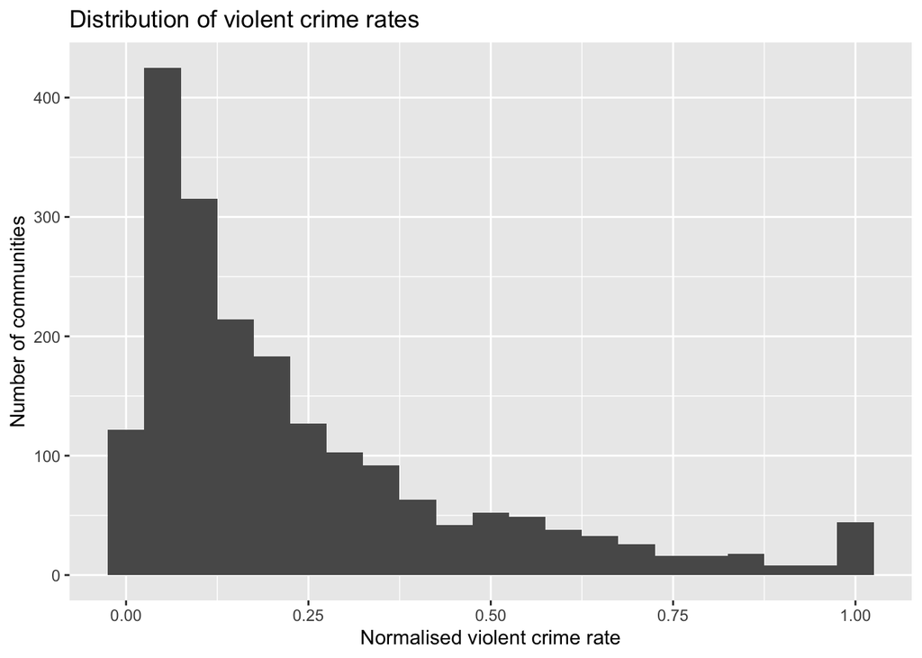

```r
## Stage1.4 Data Visualisation

library(tidyverse)

# Distribution of violent crime rates
ggplot(data = crime_selected,
       mapping = aes(x = ViolentCrime)) +
  geom_histogram(binwidth = 0.05) +
  labs(
    title = "Distribution of violent crime rates",
    x = "Normalised violent crime rate",
    y = "Number of communities"
  )
```

this histogram shows a positively skewed distribution of normalised violent crime rates. Most communities have relatively low crime rate values, with the highest concentration occurring around 0.05. The frequency decreases as crime values increase. There are also some observations with particularly high crime values near 1. This suggests that there is variation in violent crime rates across communities, which we aim to investigate using socioeconomic variables.

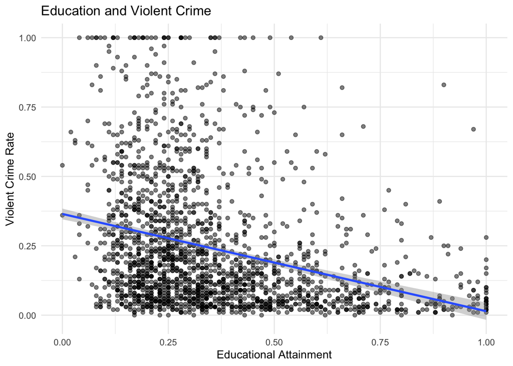

```r
ggplot(data = crime_selected,
       aes(x = Education, y = ViolentCrime)) +
  geom_point(alpha = 0.5) +
  geom_smooth(method = "lm", se = TRUE) +
  labs(
    title = "Education and Violent Crime",
    x = "Educational Attainment",
    y = "Violent Crime Rate"
  ) +
  theme_minimal()
```

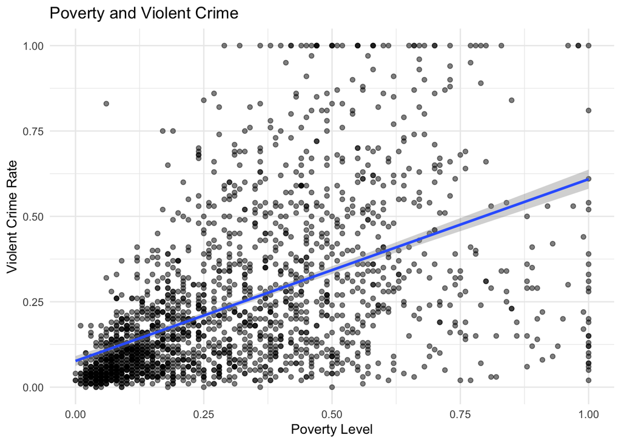

```r
ggplot(data = crime_selected,
       aes(x = Poverty, y = ViolentCrime)) +
  geom_point(alpha = 0.5) +
  geom_smooth(method = "lm", se = TRUE) +
  labs(
    title = "Poverty and Violent Crime",
    x = "Poverty Level",
    y = "Violent Crime Rate"
  ) +
  theme_minimal()
```

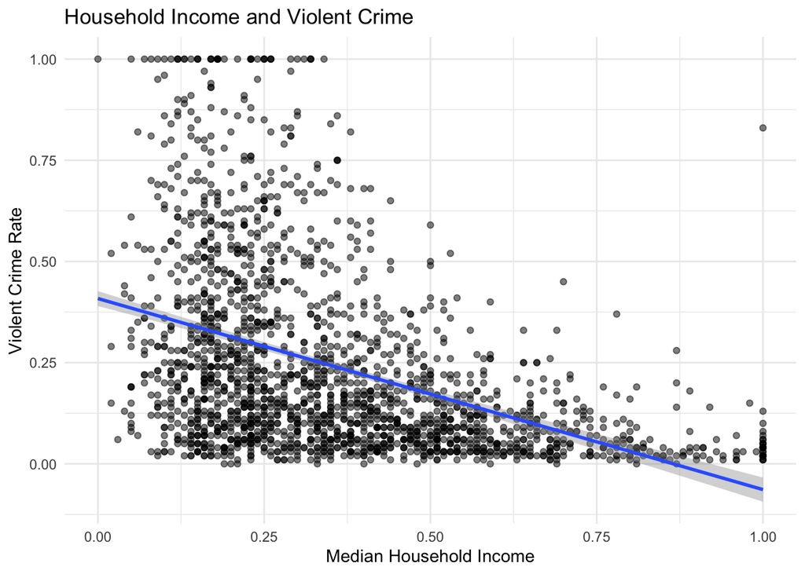

```r
ggplot(data = crime_selected,
       aes(x = MedianHouseholdIncome, y = ViolentCrime)) +
  geom_point(alpha = 0.5) +
  geom_smooth(method = "lm", se = TRUE) +
  labs(
    title = "Household Income and Violent Crime",
    x = "Median Household Income",
    y = "Violent Crime Rate"
  ) +
  theme_minimal()
```

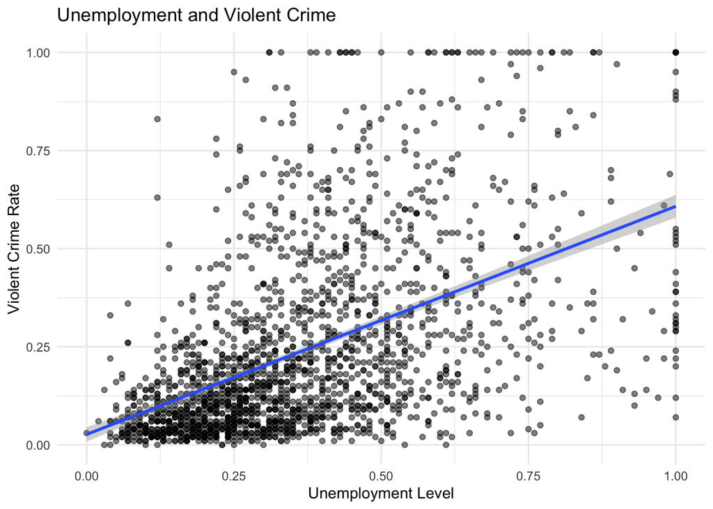

```r
ggplot(data = crime_selected,
       aes(x = Unemployment, y = ViolentCrime)) +
  geom_point(alpha = 0.5) +
  geom_smooth(method = "lm", se = TRUE) +
  labs(
    title = "Unemployment and Violent Crime",
    x = "Unemployment Level",
    y = "Violent Crime Rate"
  ) +
  theme_minimal()
```

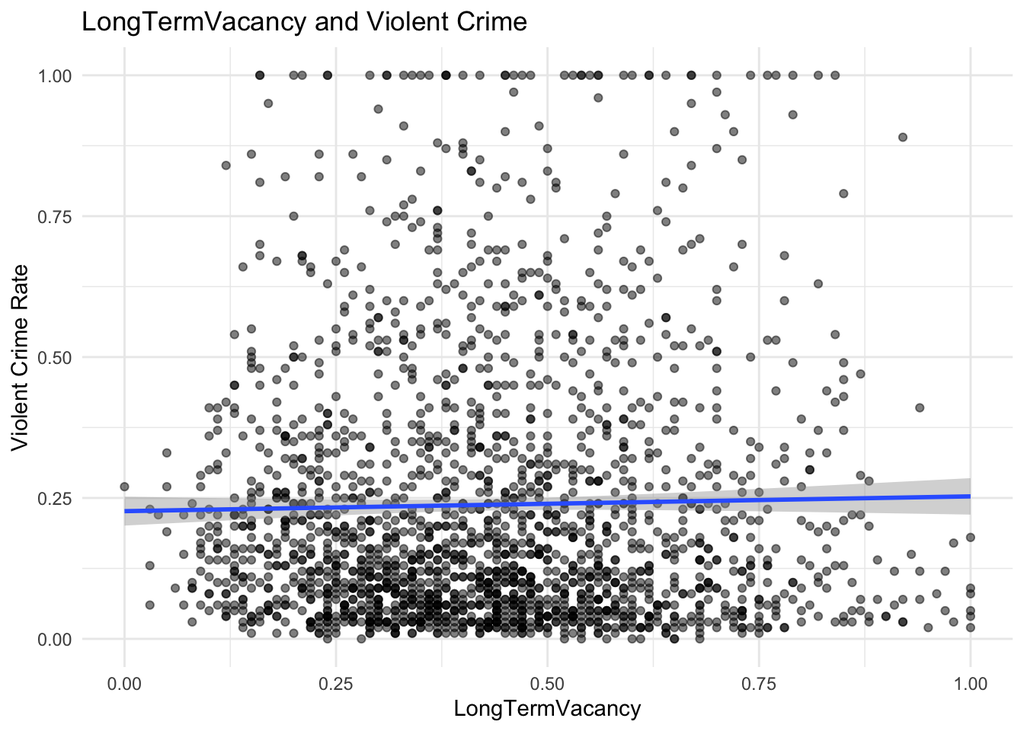

```r
ggplot(data = crime_selected,
       aes(x = LongTermVacancy, y = ViolentCrime)) +
  geom_point(alpha = 0.5) +
  geom_smooth(method = "lm", se = TRUE) +
  labs(
    title = "LongTermVacancy and Violent Crime",
    x = "LongTermVacancy",
    y = "Violent Crime Rate"
  ) +
  theme_minimal()
```

```r
## Stage3.1  Descriptive Statistics
eda_data <- crime_selected %>%
  select(-Community)

descriptive_stats <- data.frame(
  Variable = names(eda_data),
  Mean = round(sapply(eda_data, mean), 3),
  Median = round(sapply(eda_data, median), 3),
  SD = round(sapply(eda_data, sd), 3),
  Minimum = round(sapply(eda_data, min), 3),
  Maximum = round(sapply(eda_data, max), 3)
)

descriptive_stats
```

```
##                                    Variable  Mean Median    SD Minimum Maximum
## ViolentCrime                   ViolentCrime 0.238   0.15 0.233       0       1
## Poverty                             Poverty 0.303   0.25 0.228       0       1
## MedianHouseholdIncome MedianHouseholdIncome 0.361   0.32 0.209       0       1
## Unemployment                   Unemployment 0.364   0.32 0.202       0       1
## Education                         Education 0.362   0.31 0.209       0       1
## LongTermVacancy             LongTermVacancy 0.433   0.42 0.189       0       1
```

```r
## Stage 3.2 Correlation Analysis
cor_matrix <- cor(
  eda_data,
  use = "pairwise.complete.obs",
  method = "pearson"
)

round(cor_matrix, 2)
```

```
##                       ViolentCrime Poverty MedianHouseholdIncome Unemployment
## ViolentCrime                  1.00    0.52                 -0.42         0.50
## Poverty                       0.52    1.00                 -0.79         0.78
## MedianHouseholdIncome        -0.42   -0.79                  1.00        -0.65
## Unemployment                  0.50    0.78                 -0.65         1.00
## Education                    -0.31   -0.39                  0.68        -0.57
## LongTermVacancy               0.02    0.22                 -0.21         0.28
##                       Education LongTermVacancy
## ViolentCrime              -0.31            0.02
## Poverty                   -0.39            0.22
## MedianHouseholdIncome      0.68           -0.21
## Unemployment              -0.57            0.28
## Education                  1.00           -0.21
## LongTermVacancy           -0.21            1.00
```

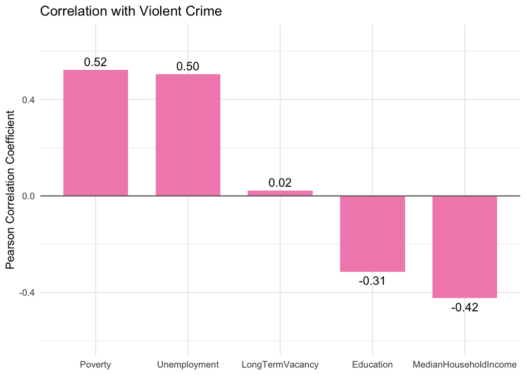

```r
## Stage 3.4 Correlation bar chart

# Extract correlations with violent crime
crime_correlations <- cor_matrix["ViolentCrime", ]

# Remove violent crime's correlation with itself
crime_correlations <- crime_correlations[
  names(crime_correlations) != "ViolentCrime"
]

# Convert into a data frame
cor_df <- data.frame(
  Variable = names(crime_correlations),
  Correlation = as.numeric(crime_correlations)
)

# Create bar chart
ggplot(cor_df,
       aes(x = reorder(Variable, -Correlation),
           y = Correlation)) +
  geom_col(fill = "#F28DBB", width = 0.7) +
  geom_text(
    aes(label = sprintf("%.2f", Correlation)),
    vjust = ifelse(cor_df$Correlation >= 0, -0.5, 1.5),
    size = 4
  ) +
  geom_hline(yintercept = 0, colour = "grey40") +
  scale_y_continuous(limits = c(-0.6, 0.65)) +
  labs(
    title = "Correlation with Violent Crime",
    x = NULL,
    y = "Pearson Correlation Coefficient"
  ) +
  theme_minimal()
```

Poverty (r = 0.52) and unemployment (r = 0.50) have the strongest positive correlations with violent crime, suggesting that communities with higher levels of poverty and unemployment tend to have higher crime rates. On the other hand, median household income (r = -0.42) and education (r = -0.31) have negative correlations, meaning that communities with higher incomes and education levels generally have lower crime rates. Long-term housing vacancy (r = 0.02) shows almost no correlation with violent crime.

# Stage4 Modeling Data

### 4.1 Model Selection

ViolentCrime is a continuous outcome, and this investigation examines how several socioeconomic variables are associated with it simultaneously. So we select Multiple linear regression as the main modelling method. The model will include Poverty, MedianHouseholdIncome, Unemployment, Education and LongTermVacancy. Model fit and residuals will be examined to assess whether this method provides a reasonable summary of the relationships in the data.

### 4.2 Model Fitting and Results

```r
final_model <- lm(
  ViolentCrime ~ Poverty + MedianHouseholdIncome +
    Unemployment + Education + LongTermVacancy,
  data = crime_selected
)

model_summary <- summary(final_model)
```

### 4.3 Model Evaluation

```r
model_fit <- data.frame(
  R_squared = model_summary$r.squared,
  Adjusted_R_squared = model_summary$adj.r.squared,
  Residual_SE = model_summary$sigma
)

knitr::kable(
  model_fit,
  digits = 3,
  col.names = c("R-squared", "Adjusted R-squared", "Residual standard error"),
  caption = "Model fit"
)
```

Model fit

| R-squared | Adjusted R-squared | Residual standard error |
| --- | --- | --- |
| 0.32 | 0.318 | 0.192 |

The model accounted for approximately 32.0% of the variation in violent crime rates (R² = 0.320; adjusted R² = 0.318). This describes how well the model fits the data used in the analysis; it is not a prediction accuracy score for new communities.

```r
 crime_evaluate <- linear_reg() %>%
  set_engine("lm") %>%
fit(ViolentCrime ~ Poverty + MedianHouseholdIncome +
    Unemployment + Education + LongTermVacancy,
  data = crime_selected) %>%
  tidy()
```

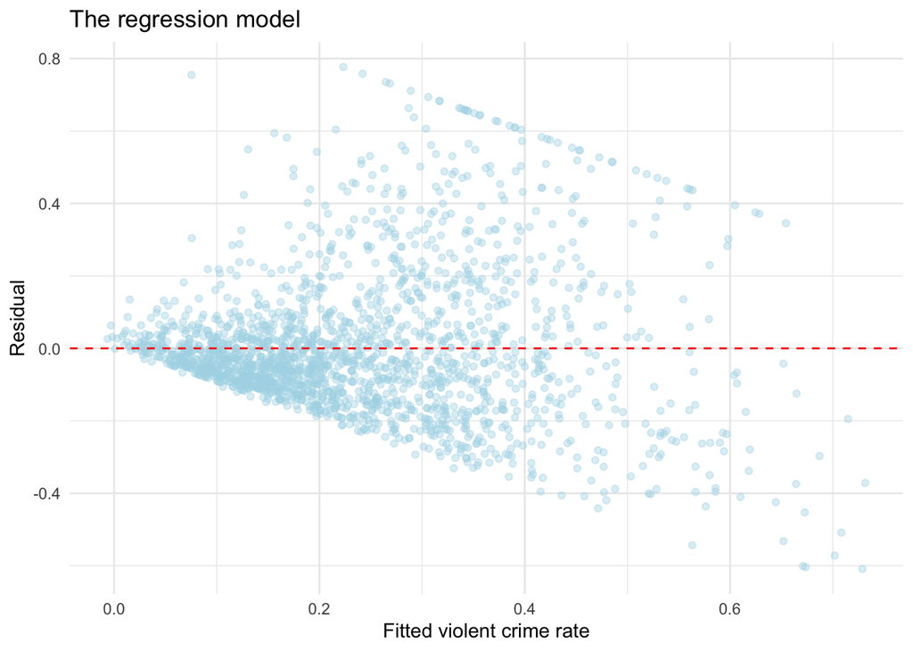

```r
residual_data <- data.frame(
  Fitted = fitted(final_model),
  Residuals = residuals(final_model)
)

ggplot(residual_data, aes(x = Fitted, y = Residuals)) +
  geom_point(alpha = 0.4, colour = "lightblue") +
  geom_hline(yintercept = 0, linetype = "dashed", colour = "red") +
  labs(
    title = "The regression model",
    x = "Fitted violent crime rate",
    y = "Residual"
  ) +
  theme_minimal()
```

The residuals become more spread out at higher fitted values, suggesting that the model errors may be less consistent for communities with higher predicted crime rates. The model should therefore be interpreted with caution in this range.

### 4.4 Limitations and Possible Improvements

The residual plot suggests that the constant-variance assumption may not hold equally well across the range of fitted values. A future analysis could investigate whether a different model specification improves this pattern. Since the data describe communities rather than individuals, the results should not be used to make claims about individual people or to label particular communities. The analysis identifies associations and does not establish causation.

### 4.5 predictive Modeling

```r
set.seed(1234)
crime_split <- initial_split(crime_selected)
crime_train <- training(crime_split)
crime_test  <- testing(crime_split)
```

```r
crime_rec_1 <- recipe(
  ViolentCrime ~ Poverty + MedianHouseholdIncome +
    Unemployment + Education + LongTermVacancy,
  data = crime_selected) %>%
  step_dummy(all_nominal_predictors())
```

```r
crime_mod_1 <- linear_reg() %>%
  set_engine("lm")
```

```r
crime_wflow_1 <- workflow() %>%
  add_recipe(crime_rec_1) %>%
  add_model(crime_mod_1)
```

```r
crime_fit_1 <- fit(crime_wflow_1, data = crime_selected)
```

```r
crime_predictions_1 <- predict(
  crime_fit_1,
  new_data = crime_test
  ) %>%
  bind_cols(crime_test %>% select(ViolentCrime))
```

```r
crime_metrics_1 <- crime_predictions_1 %>%
  metrics(truth = ViolentCrime,
          estimate = .pred)
crime_metrics_1
```

```
## # A tibble: 3 × 3
##   .metric .estimator .estimate
##   <chr>   <chr>          <dbl>
## 1 rmse    standard       0.189
## 2 rsq     standard       0.349
## 3 mae     standard       0.133
```

## Ethical Concern

In this report, we can see some of the variables have a positive relationship with violent crime. However, the correlation does not imply causation. There are many other factors that can be involved but not take in account. We cannot guarantee the other variables every case in our data is under the same condition. In addition, these data are describing a historical context from 1990, it cannot represent the relationship of violent crime with all those explanatory variables. A huge difference between the 90s and modern day have been made, for example there are changes law, increase in life conditions, compulsory education etc.